# Fitting Bayesian Multilevel Single Case models using bmscstan

Michele Scandola

2020-11-07

The package **bmscstan** provides useful functions to fit Bayesian Multilevel Single Case models (BMSC) using as backend *Stan* (Carpenter et al. 2017).

This approach is based on the seminal approach of the Crawford’s tests (Crawford and Howell 1998; Crawford and Garthwaite 2005; Crawford et al. 2010), using a small control sample of individuals, to see whether the performance of the single case deviates from them. Unfortunately, Crawford’s tests are limited to a number of specific experimental designs that do not allow researchers to use complex experimental designs.

The BMSC approach is born mainly to deal with this problem: its purpose is, in fact, to allow the fitting of models with the same flexibility of a Multilevel Model, with single case and controls data.

The core function of the **bmscstan** package is `BMSC`, whose theoretical assumptions, and its validation are reported in (Scandola and Romano 2020).

The syntax used by the `BMSC` function is extremely similar to the syntax used in the `lme4` package. However, the specification of random effects is limited, but it can cover the greatest part of cases (for further details, please see `?bmscstan::randomeffects`).

## Example on real data

In order to show an example on the use of the **bmscstan** package, the datasets in this package will be used.

In these datasets we have data coming from a Body Sidedness Effect paradigm (Ottoboni et al. 2005; Tessari et al. 2012), that is a Simon-like paradigm useful to measure body representation.

In this experimental paradigm, participants have to answer to a circle showed in the centre of the computer screen, superimposed to an irrelevant image of a left or right hand, or to a left or right foot.

The circle can be of two colors (e.g. red or blue), and participants have to press one button with the left when the circle is of a specific colour, and with the right hand when the circle is of the another colour.

When the irrelevant background image (foot or hand) is incongruent with the hand used to answer, the reaction times and frequency of errors are higher.

The two irrelevant backgrounds are administered in different experimental blocks.

This is considered an effect of the body representation.

In the package there are two datasets, one composed by 16 healthy control participants, and the other one by an individual affected by right unilateral brachial plexus lesion (however, s/he could independently press the keyboard buttons).

## Explore the data

The datasets are called `data.pt` for the single case, and `data.ctrl` for the control group, and they can be loaded using `data(BSE)`.

In these datasets there are the Reaction Times `RT`, a `Body.District` factor with levels FOOT and HAND, a `Congruency` factor (levels: Congruent, Incongruent), and a `Side` factor (levels: Left, Right). In the `data.ctrl` dataset there also is an `ID` factor, representing the different 16 control participants.

```r
library(bmscstan)

data(BSE)

str(data.pt)
```

```
#> 'data.frame':    467 obs. of  4 variables:
#>  $ RT           : int  562 424 411 491 439 593 504 483 467 413 ...
#>  $ Body.District: Factor w/ 2 levels "FOOT","HAND": 1 1 1 1 1 1 1 1 1 1 ...
#>  $ Congruency   : Factor w/ 2 levels "Congruent","Incongruent": 1 2 2 1 1 2 2 1 1 2 ...
#>  $ Side         : Factor w/ 2 levels "Left","Right": 1 2 1 2 1 1 2 1 2 2 ...
```

```r
str(data.ctrl)
```

```
#> 'data.frame':    4049 obs. of  5 variables:
#>  $ RT           : int  785 641 938 841 486 425 408 394 611 387 ...
#>  $ Body.District: Factor w/ 2 levels "FOOT","HAND": 1 1 1 1 1 1 1 1 1 1 ...
#>  $ Congruency   : Factor w/ 2 levels "Congruent","Incongruent": 2 2 2 2 2 2 1 1 1 1 ...
#>  $ Side         : Factor w/ 2 levels "Left","Right": 1 1 1 1 2 1 1 1 2 2 ...
#>  $ ID           : Factor w/ 16 levels "HN_017","HN_019",..: 1 1 1 1 1 1 1 1 1 1 ...
```

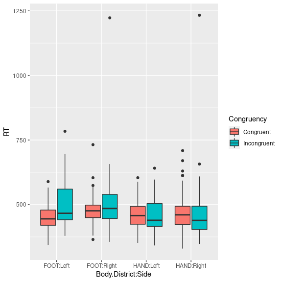

```r
ggplot(data.pt, aes(y = RT, x = Body.District:Side , fill = Congruency))+
  geom_boxplot()
```

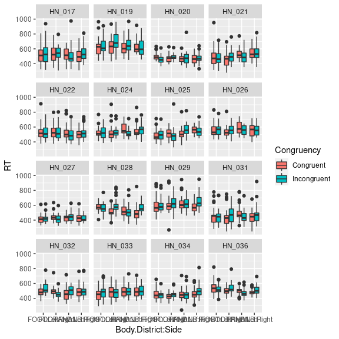

```r
ggplot(data.ctrl, aes(y = RT, x = Body.District:Side , fill = Congruency))+
  geom_boxplot()+
  facet_wrap( ~ ID , ncol = 4)
```

These data seem to have some outliers. Let see if they are normally distributed.

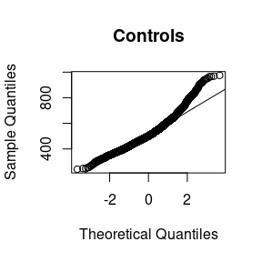

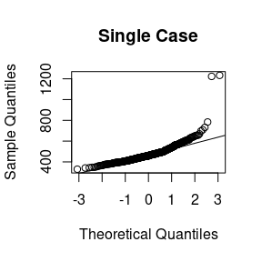

```r
qqnorm(data.ctrl$RT, main = "Controls")
qqline(data.ctrl$RT)

qqnorm(data.pt$RT, main = "Single Case")
qqline(data.pt$RT)
```

They are not normally distributed. Outliers will be removed by using the `boxplot.stats` function.

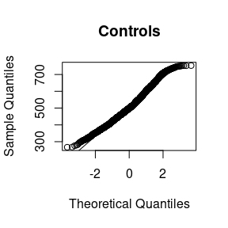

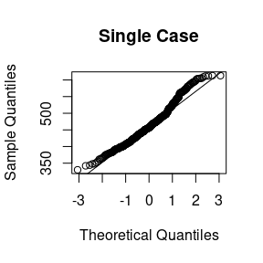

```r
out <- boxplot.stats( data.ctrl$RT )$out
data.ctrl <- droplevels( data.ctrl[ !data.ctrl$RT %in% out , ] )

out <- boxplot.stats( data.pt$RT )$out
data.pt <- droplevels( data.pt[ !data.pt$RT %in% out , ] )

qqnorm(data.ctrl$RT, main = "Controls")
qqline(data.ctrl$RT)

qqnorm(data.pt$RT, main = "Single Case")
qqline(data.pt$RT)
```

They are not perfect, but definitively better.

## Deciding the contrasts and the random effects part

First of all, there is the necessity to think to our hypotheses, and setting the contrast matrices consequently.

In all cases, our factors have only two levels. Therefore, we set the factors with a Treatment Contrasts matrix, with baseline level for `Side` the *Left* level, for `Congruency` the *Congruent* level, and for `Body.District` the *FOOT* level.

In this way, each coefficient will represent the difference between the two levels.

```r
contrasts( data.ctrl$Side )          <- contr.treatment( n = 2 )
contrasts( data.ctrl$Congruency )    <- contr.treatment( n = 2 )
contrasts( data.ctrl$Body.District ) <- contr.treatment( n = 2 )

contrasts( data.pt$Side )            <- contr.treatment( n = 2 )
contrasts( data.pt$Congruency )      <- contr.treatment( n = 2 )
contrasts( data.pt$Body.District )   <- contr.treatment( n = 2 )
```

The use of the `BMSC` function, for those who are used to `lme4` or `brms` syntax should be straightforward.

In this case, we want to fit the following model:

`RT ~ Body.District * Congruency * Side + (Congruency * Side | ID / Body.District)`

Unfortunately, `BMSC` does not directly allow the syntax `ID / Body.District` in the specification of the random effects.

In any case, taking into consideration that `(1 | ID / Body.District)` is a short version of `(1 | ID : Body.District) + (1 | ID)`, it is possible to solve this problem.

It is necessary to create a new variable for `ID : Body.District`

```r
data.ctrl$BD_ID <- interaction( data.ctrl$Body.District , data.ctrl$ID )
```

and the model would be:

`RT ~ Body.District * Congruency * Side + (Congruency * Side | BD_ID) + (Congruency * Side | ID)`

## Fitting the BMSC model

At this point, fitting the model is easy, and it can be done with the use of a single function.

```r
mdl <- BMSC(formula = RT ~ Body.District * Congruency * Side +
             (Congruency * Side | ID) + (Congruency * Side | BD_ID),
             data_ctrl = data.ctrl,
             data_sc = data.pt,
             cores = 1,
             seed = 2020)
```

After fitting the model, we should check its quality by means of Posterior Predictive P-Values (Gelman 2013) with the `bmscstan::pp_check` function.

Thanks to this graphical function, we will see if the observed data and the data sampled from the posterior distributions of our BMSC model are similar.

If we observe strong deviations, it means that your BMSC model is not adequately describing your data. In this case, you might want to change the priors distribution (see the `help` page), change the random effects structure, or transform your dependent variable (using the logarithm or other math functions).

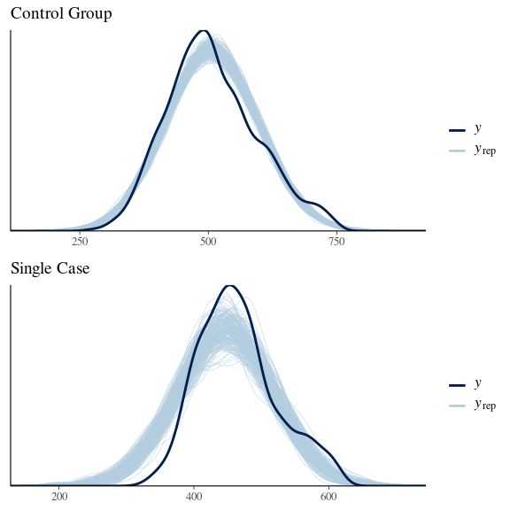

```r
pp_check( mdl )
```

In both the controls and the single case data, the Posterior Predictive P-Values check seems to adequately resemble the observed data.

A further control on our model is given by checking the Effective Sample Size (ESS) for each coefficient and the $\hat{R}$ diagnostic index (Gelman and Rubin 1992).

The ESS is the “effective number of simulation draws” for any coefficient, namely the approximate number of independent draws, taking into account that the various simulations in a Monte Carlo Markov Chain (MCMC) are not independent each other. For further details, see an introductory book in Bayesian Statistics. A good ESS estimates should be $ESS > 100$ or $ESS > 10\%$ of the total draws (remembering that you should remove the burn-in simulations from the total iterations counting).

The $\hat{R}$ is an index of the convergence of the MCMCs. In `BMSC` the default is 4. Usually, MCMCs are considered convergent when $\hat{R} < 1.1$ (*Stan* default).

In order to check these values, the `summary.BMSC` function is needed (see next section).

## The `summary.BMSC` output

The output of the `brmscstan::summary.BMSC` function is divided in four main parts:

1. In the first part, the model and the selected priors are recalled.
2. In the second part, the coefficients of the fixed effects for the control group are shown.
3. In the third part, the coefficients of the fixed effects for the single case are shown.
4. In the fourth and last part, the fixed effects coefficients for the difference between the single case and the control group are shown.

```r
print( summary( mdl ) , digits = 3 )
```

```
#>
#> Bayesian Multilevel Single Case model
#>
#> RT ~ Body.District * Congruency * Side + (Congruency * Side |
#>     ID) + (Congruency * Side | BD_ID)
#>
#> [1] "Priors for the regression coefficients: normal distribution; Dispersion parameter (scale or sigma): 10"
#>
#>
#>   Fixed Effects for the Control Group
#>
#>                                    mean se_mean   sd   2.5%    25%    50%
#> (Intercept)                      199.88  0.0670 7.79 184.55 194.52 199.90
#> Body.District2                    17.20  0.0618 5.80   6.22  13.14  17.11
#> Congruency2                       16.10  0.0844 6.75   4.08  11.33  15.72
#> Side2                             19.11  0.0912 7.50   5.01  13.88  18.95
#> Body.District2:Congruency2       -10.03  0.0422 4.99 -19.84 -13.38  -9.97
#> Body.District2:Side2              -4.87  0.0448 4.85 -14.37  -8.15  -4.92
#> Congruency2:Side2                 -7.22  0.0805 7.76 -22.65 -12.40  -7.13
#> Body.District2:Congruency2:Side2   6.42  0.0614 6.25  -5.99   2.26   6.53
#>                                     75%   97.5% n_eff Rhat     BF10
#> (Intercept)                      205.20 215.072 13519    1 1.58e+49
#> Body.District2                    21.15  28.931  8823    1     54.8
#> Congruency2                       20.53  30.272  6382    1     21.2
#> Side2                             24.30  33.919  6763    1     31.9
#> Body.District2:Congruency2        -6.65  -0.375 13994    1     3.81
#> Body.District2:Side2              -1.54   4.553 11759    1    0.796
#> Congruency2:Side2                 -1.90   7.653  9310    1     1.17
#> Body.District2:Congruency2:Side2  10.69  18.550 10362    1     1.13
#>
#>        mean se_mean    sd 2.5%  25%  50%  75% 97.5% n_eff Rhat
#> sigmaC 75.7 0.00662 0.882   74 75.1 75.7 76.3  77.5 17715    1
#>
#>
#>   Fixed Effects for the Patient
#>
#>                                   mean se_mean   sd  2.5%   25%   50%    75%
#> (Intercept)                      394.8  0.0715 6.39 382.1 390.5 394.9 399.27
#> Body.District2                    40.5  0.0762 6.82  27.2  35.8  40.5  45.21
#> Congruency2                       47.1  0.0804 7.19  33.5  42.2  47.0  52.01
```

[output cut: 24 more lines]

```
#> Body.District2:Side2             -16.61  0.0598 7.59 -31.49 -21.8 -16.68 -11.37
#> Congruency2:Side2                 -7.02  0.0698 7.99 -22.67 -12.4  -6.99  -1.68
#> Body.District2:Congruency2:Side2 -16.85  0.0624 8.51 -33.74 -22.4 -16.91 -11.10
#>                                    97.5% n_eff Rhat BF10
#> (Intercept)                      210.071 15448    1  Inf
#> Body.District2                    36.945 12250    1  134
#> Congruency2                       45.651 11283    1 1275
#> Side2                             46.469 10561    1  800
#> Body.District2:Congruency2        -1.750 15118    1 8.47
#> Body.District2:Side2              -1.474 16132    1 7.31
#> Congruency2:Side2                  8.566 13132    1 1.15
#> Body.District2:Congruency2:Side2  -0.122 18626    1 6.37
#>
#>        mean se_mean   sd 2.5%  25%  50% 75% 97.5% n_eff Rhat
#> sigmaP 64.3  0.0203 2.65 59.3 62.5 64.2  66  69.7 17052    1
```

In the second and fourth part of the output, we can observe a descriptive summary reporting the mean, the standard error, the standard deviation, the $2.5\%$, $25%$, $50\%$, $75\%$ and $97.5\%$ of the posterior distributions of each coefficient. If we want the $95\%$ Credible Interval, we can consider only the $2.5\%$ and $97.5\%$ extremes. Then, two diagnostic indexes are reported: the `n_eff` parameter, that is the *ESS*, and the `Rhat` ($\hat{R}$). Finally, the Savage-Dickey Bayes Factor is reported (*BF10*).

In the third part the diagnostic indexes are not reported because these coefficients are computed as marginal probabilities from the probabilities summarized in the second and fourth part.

## Understanding the `summary.BMSC` output

### Checking the diagnostic indexes

The first step should be controlling the diagnostic indexes.

In this model, all `n_eff` are greater than the $10\%$ of the total iterations (default iterations: 4000, default warmup iterations: 2000, default chains: 4 = 800). Also, all $\hat{R}s < 1.1$. Finally, we already saw that the Posterior Predictive P-values are showing that the model is representative of the data.

### The Control Group results

Then, observing what the fixed effects of the Control group are showing is important before of seeing the differences with the single case.

In this analysis, there are 5 fixed effects which $BF_{10}$ is greater than 3 (Raftery 1995).

- Intercept $BF_{10} > 150$, $\mu = 199.88$, $95\%~CI = [184.55; 215.072]$.
- Body District $BF_{10} = 54.8$, $\mu = 17.20$, $95\%~CI = [6.22; 28.931]$.
- Congruency $BF_{10} = 21.2$, $\mu = 16.10$, $95\%~CI = [4.08; 30.272]$.
- Side $BF_{10} = 31.9$, $\mu = 19.11$, $95\%~CI = [5.01; 33.919]$.
- Body District : Congruency $BF_{10} = 3.81$, $\mu = -10.03$, $95\%~CI = [-19.84; -0.375]$.

We can have a general overview of the coefficients of the model with the `plot.BMSC` function.

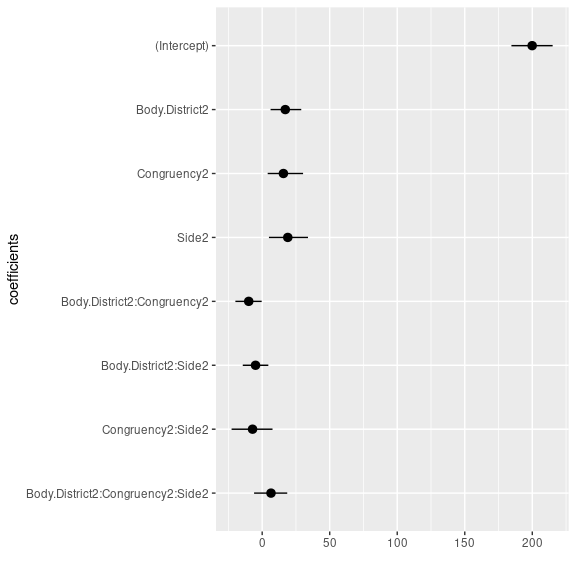

```r
plot( mdl , who = "control" )
```

The interaction between Body District and Congruency needs a further analysis to better understand the phenomenon. It comes useful the function `pairwise.BMSC`.

```r
pp <- pairwise.BMSC(mdl , contrast = "Body.District2:Congruency2" , who = "control")

print( pp , digits = 3 )
```

```
#>
#> Pairwise Bayesian Multilevel Single Case contrasts of coefficients divided by Body.District2:Congruency2
#>
#>
#>
#>   Marginal distributions
#>
#>                  mean se_mean    sd 2.5% 25% 50% 75% 97.5% BF10 (not zero)
#> FOOT Incongruent  216   0.109  9.77  197 209 216 222   236        2.87e+32
#> FOOT Congruent    200   0.087  7.79  185 195 200 205   215        1.58e+49
#> HAND Incongruent  223   0.126 11.29  202 215 223 231   246        1.47e+25
#> HAND Congruent    217   0.104  9.31  199 211 217 224   235        5.05e+30
#>
#>
#>
#>   Table of contrasts
#>
#>                                       mean se_mean   sd   2.5%    25%    50%
#> FOOT Incongruent - FOOT Congruent    16.10  0.0754 6.75   4.08  11.33  15.72
#> FOOT Incongruent - HAND Incongruent  -7.16  0.0738 6.60 -20.06 -11.67  -7.12
#> FOOT Incongruent - HAND Congruent    -1.10  0.0972 8.70 -17.63  -7.14  -1.14
#> FOOT Congruent - HAND Incongruent   -23.27  0.1014 9.07 -41.72 -29.23 -22.89
#> FOOT Congruent - HAND Congruent     -17.20  0.0649 5.80 -28.93 -21.15 -17.11
#> HAND Incongruent - HAND Congruent     6.07  0.0867 7.76  -7.95   0.85   5.60
#>                                        75% 97.5%   BF10
#> FOOT Incongruent - FOOT Congruent    20.53 30.27 21.239
#> FOOT Incongruent - HAND Incongruent  -2.62  5.64  1.171
#> FOOT Incongruent - HAND Congruent     4.54 16.44  0.889
#> FOOT Congruent - HAND Incongruent   -16.89 -6.35 39.246
#> FOOT Congruent - HAND Congruent     -13.14 -6.22 61.521
#> HAND Incongruent - HAND Congruent    11.01 22.25  0.963
```

The output of this function is divided in two parts:

- a first part, called “Marginal distributions”, where the marginal distributions of each level of the coefficients are reported with a $BF_{10}$ against zero.
- a second part, called “Table of contrasts”, with all possible pairwise comparisons and their $BF_{10}$.

It is also possible to plot the results of this function with the use of `plot.pairwise.BMSC`.

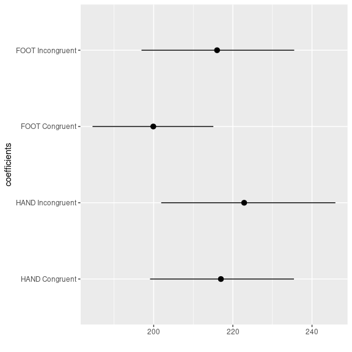

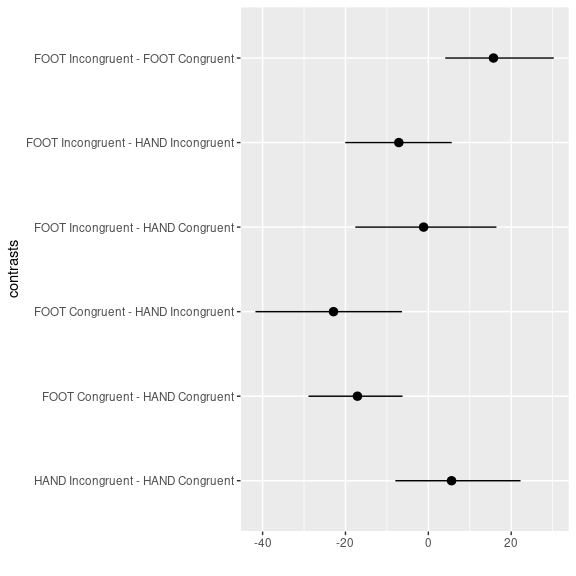

```r
plot( pp )
```

Finally, it is possible to plot marginal posterior distributions for each effects with $BF_{10} > 3$.

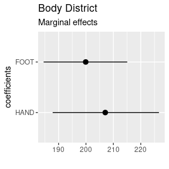

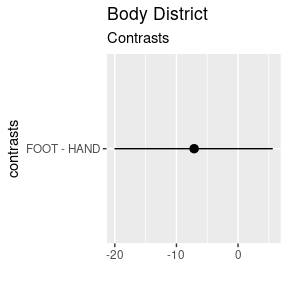

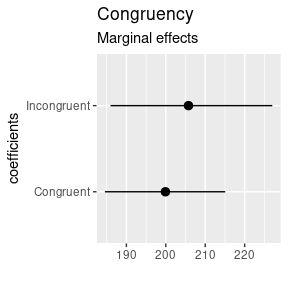

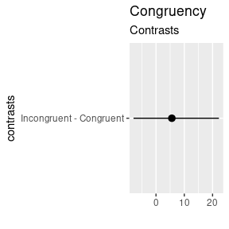

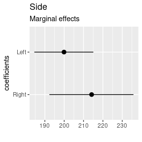

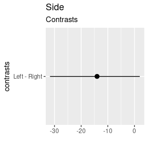

```r
p1 <- pairwise.BMSC(mdl , contrast = "Body.District2" ,  who = "control" )

plot( p1 )[[1]] +
  ggtitle("Body District" , subtitle = "Marginal effects")

plot( p1 )[[2]] +
  ggtitle("Body District" , subtitle = "Contrasts")

p2 <- pairwise.BMSC(mdl , contrast = "Congruency2" ,  who = "control" )

plot( p2 )[[1]] +
  ggtitle("Congruency" , subtitle = "Marginal effects")

plot( p2 )[[2]] +
  ggtitle("Congruency" , subtitle = "Contrasts")

p3 <- pairwise.BMSC(mdl , contrast = "Side2" ,  who = "control" )

plot( p3 )[[1]] +
  ggtitle("Side" , subtitle = "Marginal effects")

plot( p3 )[[2]] +
  ggtitle("Side" , subtitle = "Contrasts")
```

### The differences between the Control Group and the Single Case

Finally, the difference between the Control Group and the Single Case is of interest.

A general plot can be obtained in the following way, plotting both the Control Group and the Single Case:

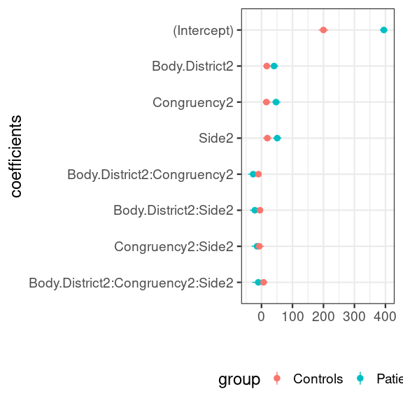

```r
plot( mdl ) +
  theme_bw( base_size = 18 )+
  theme( legend.position = "bottom",
         legend.direction = "horizontal")
```

or plotting only the difference

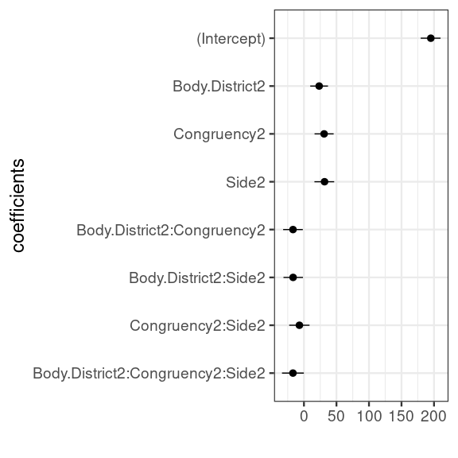

```r
plot( mdl ,who = "delta" ) +
  theme_bw( base_size = 18 )
```

The relevant coefficients are:

The Intercept coefficient is showing us that the single case is generally slower than the Control Sample (generally speaking, when you analyse healthy controls against a single case with a specific disease, the single case is slower).

All the main effects can be further analysed by simply looking at their estimates (knowing the contrast matrix and the direction of the estimate you can understand which level is greater than the other), or by means of the `pairwise.BMSC` function, if you also want marginal effects and automatic plots.

The interactions require the use of the `pairwise.BMSC` function.

#### The Body District : Congruency interaction:

```r
p4 <- pairwise.BMSC(mdl , contrast = "Body.District2:Congruency2" , who = "delta")

print( p4 , digits = 3 )
```

```
#>
#> Pairwise Bayesian Multilevel Single Case contrasts of coefficients divided by Body.District2:Congruency2
#>
#>
#>
#>   Marginal distributions
#>
#>                  mean se_mean    sd 2.5% 25% 50% 75% 97.5% BF10 (not zero)
#> FOOT Congruent    195  0.0875  7.83  180 190 195 200   210             Inf
#> FOOT Incongruent  226  0.1137 10.17  206 219 226 233   246        2.65e+23
#> HAND Incongruent  216  0.1556 13.92  188 206 216 225   242             Inf
#> HAND Congruent    218  0.1085  9.70  199 212 219 225   237        1.02e+27
#>
#>
#>
#>   Table of contrasts
#>
#>                                       mean se_mean    sd  2.5%     25%    50%
#> FOOT Congruent - FOOT Incongruent   -31.04  0.0829  7.41 -45.7 -35.990 -31.01
#> FOOT Congruent - HAND Incongruent   -20.66  0.1398 12.51 -45.1 -29.193 -20.67
#> FOOT Congruent - HAND Congruent     -23.29  0.0777  6.95 -36.9 -28.034 -23.39
#> FOOT Incongruent - HAND Incongruent  10.38  0.1244 11.12 -11.5   3.016  10.43
#> FOOT Incongruent - HAND Congruent     7.75  0.1113  9.95 -11.6   0.939   7.69
#> HAND Incongruent - HAND Congruent    -2.63  0.1296 11.59 -25.5 -10.518  -2.57
#>                                        75%  97.5%   BF10
#> FOOT Congruent - FOOT Incongruent   -26.20 -16.30 621.74
#> FOOT Congruent - HAND Incongruent   -12.23   3.76   4.94
#> FOOT Congruent - HAND Congruent     -18.56  -9.66 174.55
#> FOOT Incongruent - HAND Incongruent  18.02  31.76   1.70
#> FOOT Incongruent - HAND Congruent    14.35  27.79   1.30
#> HAND Incongruent - HAND Congruent     5.17  20.46   1.17
```

The `pairwise.BMSC` function shows that in all cases the marginal effects of the RTs where greater than zero, but the differences where present only in the comparison between FOOT Congruent and the other cases.

```r
plot( p4 , type = "interval")
```

```r
plot( p4 , type = "area")
```

[figure not shown]

[figure not shown]

[figure not shown]

[figure not shown]

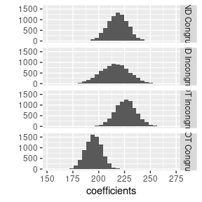

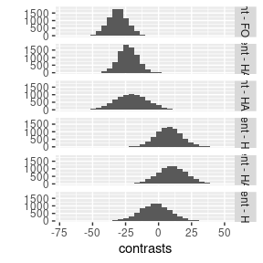

```r
plot( p4 , type = "hist")
```

In this case we can observe that the single case was more facilitated by the FOOT Congruent condition than the Control Group.

If the interpretation of the results is difficult, it can be useful look what happens in the Single Case marginal effects.

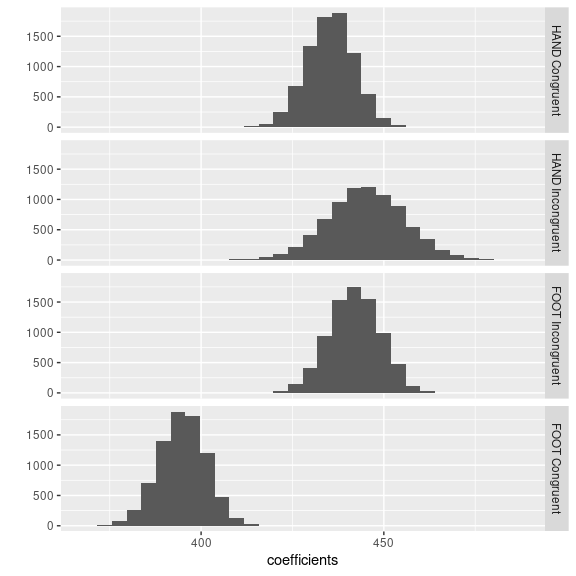

```r
p5 <- pairwise.BMSC(mdl , contrast = "Body.District2:Congruency2" ,
                    who = "singlecase")

plot( p5 , type = "hist")[[1]]
```

```r
p6 <- pairwise.BMSC(mdl , contrast = "Body.District2:Side2" , who = "delta")

print( p6 , digits = 3 )
```

```
#>
#> Pairwise Bayesian Multilevel Single Case contrasts of coefficients divided by Body.District2:Side2
#>
#>
#>
#>   Marginal distributions
#>
#>            mean se_mean    sd 2.5% 25% 50% 75% 97.5% BF10 (not zero)
#> FOOT Left   195  0.0875  7.83  180 190 195 200   210             Inf
#> FOOT Right  227  0.1166 10.43  206 219 226 234   247        8.94e+28
#> HAND Left   218  0.1085  9.70  199 212 219 225   237        1.02e+27
#> HAND Right  233  0.1428 12.77  208 225 233 242   258        3.25e+23
#>
#>
#>
#>   Table of contrasts
#>
#>                           mean se_mean    sd  2.5%    25%    50%     75%  97.5%
#> FOOT Left - FOOT Right  -31.60  0.0867  7.75 -46.5 -37.07 -31.67 -26.426 -16.11
#> FOOT Left - HAND Left   -23.29  0.0777  6.95 -36.9 -28.03 -23.39 -18.563  -9.66
#> FOOT Left - HAND Right  -38.29  0.1268 11.34 -60.6 -46.01 -38.35 -30.568 -16.24
#> FOOT Right - HAND Left    8.31  0.1122 10.03 -11.4   1.55   8.23  15.047  28.04
#> FOOT Right - HAND Right  -6.69  0.1013  9.06 -24.4 -12.83  -6.80  -0.482  11.05
#> HAND Left - HAND Right  -14.99  0.1098  9.82 -34.1 -21.60 -15.02  -8.399   4.50
#>                           BF10
#> FOOT Left - FOOT Right  737.96
#> FOOT Left - HAND Left   174.55
#> FOOT Left - HAND Right  260.44
#> FOOT Right - HAND Left    1.42
#> FOOT Right - HAND Right   1.21
#> HAND Left - HAND Right    3.13
```

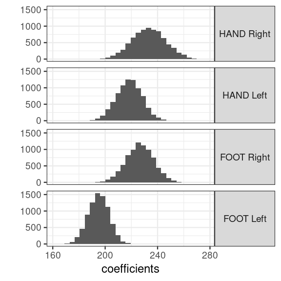

```r
plot( p6 , type = "hist")[[1]] +
  theme_bw( base_size = 18)+
  theme( strip.text.y = element_text( angle = 0 ) )
```

In this case, we can see that the left - right difference in the single case is always present, with faster RTs in the left foot than in the other cases.

#### The Body District : Congruency : Side interaction:

```r
p7 <- pairwise.BMSC(mdl ,
                    contrast = "Body.District2:Congruency2:Side2" ,
                    who = "delta")

print( p7 , digits = 3 )
```

```
#>
#> Pairwise Bayesian Multilevel Single Case contrasts of coefficients divided by Body.District2:Congruency2:Side2
#>
#>
#>
#>   Marginal distributions
#>
#>                        mean se_mean    sd 2.5% 25% 50% 75% 97.5%
#> FOOT Congruent Left     195  0.0875  7.83  180 190 195 200   210
#> FOOT Incongruent Right  251  0.1516 13.56  224 241 251 260   276
#> FOOT Incongruent Left   226  0.1137 10.17  206 219 226 233   246
#> FOOT Congruent Right    227  0.1166 10.43  206 219 226 234   247
#> HAND Incongruent Left   232  0.1365 12.21  208 224 233 241   256
#> HAND Congruent Right    233  0.1428 12.77  208 225 233 242   258
#> HAND Congruent Left     218  0.1085  9.70  199 212 219 225   237
#> HAND Incongruent Right  224  0.1778 15.90  192 213 224 234   255
#>                        BF10 (not zero)
#> FOOT Congruent Left                Inf
#> FOOT Incongruent Right        7.69e+34
#> FOOT Incongruent Left         2.65e+23
#> FOOT Congruent Right          8.94e+28
#> HAND Incongruent Left         5.83e+18
#> HAND Congruent Right          3.25e+23
#> HAND Congruent Left           1.02e+27
#> HAND Incongruent Right        5.39e+12
#>
#>
#>
#>   Table of contrasts
#>
#>                                                    mean se_mean    sd   2.5%
#> FOOT Congruent Left - FOOT Incongruent Right    -55.621  0.1353 12.10 -79.08
#> FOOT Congruent Left - FOOT Incongruent Left     -31.038  0.0829  7.41 -45.65
#> FOOT Congruent Left - FOOT Congruent Right      -31.599  0.0867  7.75 -46.47
#> FOOT Congruent Left - HAND Incongruent Left     -37.507  0.1206 10.79 -58.08
#> FOOT Congruent Left - HAND Congruent Right      -38.285  0.1268 11.34 -60.64
#> FOOT Congruent Left - HAND Congruent Left       -23.292  0.0777  6.95 -36.95
#> FOOT Congruent Left - HAND Incongruent Right    -28.635  0.1678 15.01 -57.56
#> FOOT Incongruent Right - FOOT Incongruent Left   24.583  0.1158 10.35   3.98
#> FOOT Incongruent Right - FOOT Congruent Right    24.021  0.1111  9.93   4.58
```

[output cut: 62 more lines]

```
#> FOOT Incongruent Left - FOOT Congruent Right       1.07
#> FOOT Incongruent Left - HAND Incongruent Left      1.17
#> FOOT Incongruent Left - HAND Congruent Right       1.51
#> FOOT Incongruent Left - HAND Congruent Left        1.30
#> FOOT Incongruent Left - HAND Incongruent Right     1.50
#> FOOT Congruent Right - HAND Incongruent Left       1.41
#> FOOT Congruent Right - HAND Congruent Right        1.21
#> FOOT Congruent Right - HAND Congruent Left         1.42
#> FOOT Congruent Right - HAND Incongruent Right      1.39
#> HAND Incongruent Left - HAND Congruent Right       1.32
#> HAND Incongruent Left - HAND Congruent Left        2.95
#> HAND Incongruent Left - HAND Incongruent Right     1.61
#> HAND Congruent Right - HAND Congruent Left         3.24
#> HAND Congruent Right - HAND Incongruent Right      1.70
#> HAND Congruent Left - HAND Incongruent Right       1.56
```

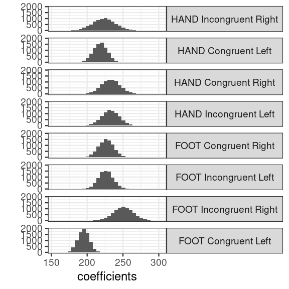

```r
plot( p7 , type = "hist")[[1]] +
  theme_bw( base_size = 18)+
  theme( strip.text.y = element_text( angle = 0 ) )
```

Here we can see that the effect was pushed by the facilitation that the single case had in the Left Congruent Foot condition compared to the Control Group.

## Conclusions

In this vignette we have seen how to use the package **bmscstan** and its functions to analyse and make sense of Single Case data.

The output of the main functions is rich of information, and the Bayesian Inference can be done by taking into account the Savage-Dickey $BF_{10}$, or the $95\%$ CI (see Kruschke 2014 for further details).

In this vignette there is almost no discussion concerning how to test the Single Case fixed effects (third part of the main output), but it was used to better understand what happens in the differences between the single case and the control group.

However, if your hypotheses focus on the behaviour of the patient, and not only on the differences between single case and the control group, it will be important to analyse in detail also that part.

# References

Carpenter, Bob, Andrew Gelman, Matthew D. Hoffman, Daniel Lee, Ben Goodrich, Michael Betancourt, Marcus Brubaker, Jiqiang Guo, Peter Li, and Allen Riddell. 2017. “<i>Stan</i> : A Probabilistic Programming Language.” *Journal of Statistical Software* 76 (1). https://doi.org/10.18637/jss.v076.i01.

Crawford, John R., and Paul H. Garthwaite. 2005. “Evaluation of criteria for classical dissociations in single-case studies by Monte Carlo simulation.” *Neuropsychology* 19 (5): 664–78. https://doi.org/10.1037/0894-4105.19.5.664.

Crawford, John R., Paul H Garthwaite, Sara Porter, and Sara Porter Point. 2010. “Point and interval estimates of effect sizes for the case-controls design in neuropsychology : Rationale , methods , implementations , and proposed reporting standards Point and interval estimates of effect sizes for the case-controls design in neuropsych” 3294. https://doi.org/10.1080/02643294.2010.513967.

Crawford, John R., and David C Howell. 1998. “Comparing an Individual ’ s Test Score Against Norms Derived from Small Samples.” *The Clinical Neuropsychologist* 12 (4): 482–86. https://doi.org/10.1076/clin.12.4.482.7241.

Gelman, Andrew. 2013. “Understanding posterior p-values.” *Electronic Journal of Statistics*, 1–8. https://doi.org/10.1214/13-EJS854.

Gelman, Andrew, and Donald B Rubin. 1992. “Inference from Iterative Simulation Using Multiple Sequences.” *Statistical Science* 7 (4): 457–72.

Kruschke, John K. 2014. *Doing Bayesian data analysis: A tutorial with R, JAGS, and Stan, second edition*. 2nd ed. Elsevier Inc. https://doi.org/10.1016/B978-0-12-405888-0.09999-2.

Ottoboni, Giovanni, Alessia Tessari, Roberto Cubelli, and Carlo Umiltà. 2005. “Is handedness recognition automatic? A study using a Simon-like paradigm.” *Journal of Experimental Psychology: Human Perception and Performance* 31 (4): 778–89. https://doi.org/10.1037/0096-1523.31.4.778.

Raftery, Adrian E. 1995. “Bayesian Model Selection in Social Research.” In *Sociological Methodology*, edited by P V Marsden, 25:111–63. 1995. Cambridge: Blackwells.

Scandola, Michele, and Daniele Romano. 2020. “Bayesian Multilevel Single Case Models Using ’Stan’. A New Tool to Study Single Cases in Neuropsychology.” PsyArXiv. https://doi.org/10.31234/osf.io/sajdq.

Tessari, Alessia, Giovanni Ottoboni, Giulia Baroni, Ed Symes, and Roberto Nicoletti. 2012. “Is access to the body structural description sensitive to a body part’s significance for action and cognition? A study of the sidedness effect using feet.” *Experimental Brain Research* 218 (4): 515–25. https://doi.org/10.1007/s00221-012-3045-4.